# Beta Bandit Gaps

Ian Osband

November 5, 2015

I want to do some simple simulations to gain some insights into Beta-Bernoulli bandits. The key to the argument for $K$-armed bandits comes from Theorem 3.5 in [this](https://www.princeton.edu/~sbubeck/SurveyBCB12.pdf) paper.

After $T$ steps with $K$ arms, at least one arm has been pulled less that $T/K$ times, and for this arm it is impossible to differentiate between a Bernoulli $\delta$ and $\delta + \sqrt{K / T}$. I will now seek to show that, if we have $K$ arms, each IID with suitable Beta prior we should be able to get this as a pretty typical outcome.

I will generate a bandit problem from the prior $Beta(\lambda, \lambda)$ with $\lambda = \sqrt{T / K}$ so that the typical standard deviation of arms is as required. My claim is that a significant portion of arms will be separated from the maximum arm by some reasonable constant to the maximum.

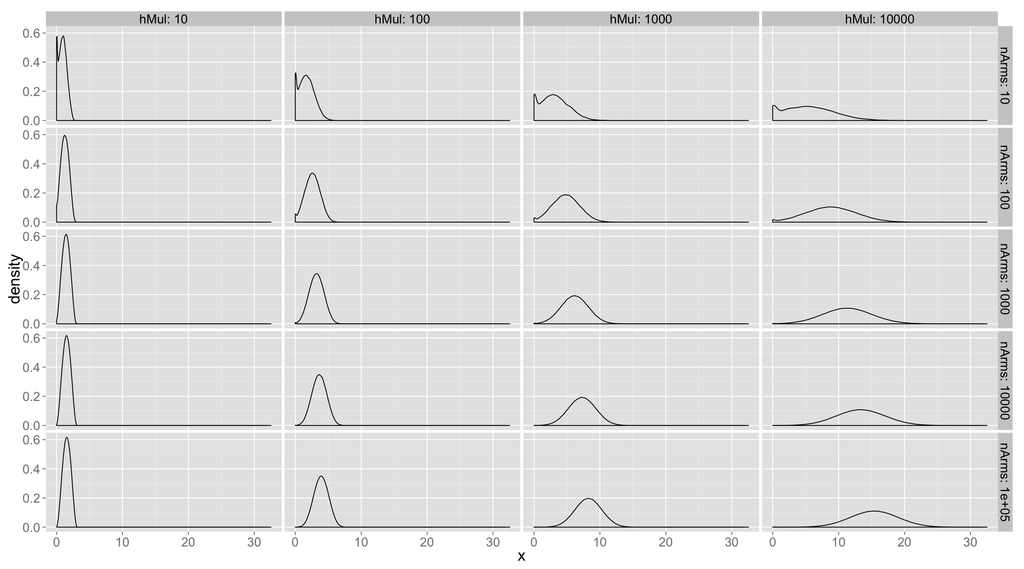

```r
gapScalings <- function(nArms, horizon){
  # gapScalings returns the gaps of the gaps of the bandit problem.
  # Here we only deal with alpha=beta --> mean=0.5
  #
  # Args:
  #   nArms - int - number of arms K
  #   horizon - int - timesteps T
  #
  # Returns:
  #   gapScales - nArms x 1 - gap / (sqrt(K / T))
  lambda <- sqrt(horizon / nArms)
  means <- rbeta(n=nArms, shape1=lambda, shape2=lambda)
  gaps <- max(means) - sort(means)
  return(gaps * lambda )
}

genScaling <- function(nArms, hMul, nSim=100) {
  # genScaling will generate several simulations of scalings.

  horizon <- nArms * hMul
  x <- gapScalings(nArms, horizon)
  for (i in 1:nSim) {
    xNew <- gapScalings(nArms, horizon)
    x <- c(x, xNew)
  }
  dt <- data.table(x=x, nArms=nArms, hMul=hMul, horizon=horizon)
  return(dt)
}

armList <- c(10, 100, 1000, 10000, 100000)
horizonMul <- c(10, 100, 1000, 10000)


dt <- data.table()
for (k in armList) {
  for (L in horizonMul) {
#     print(paste0('arms: ', k, ' hMul: ', L))
    newDt <- genScaling(nArms=k, hMul=L, nSim=min(1000, 1e6/k))
    dt <- rbind(dt, newDt)
  }
}

plt <- (ggplot(dt)
        + aes(x=x)
        + geom_density()
        + facet_grid(nArms ~ hMul, labeller=label_both))
plt
```

This faceted plot shows the distribution of gaps below optimal. This gap is normalized by the standard deviation $\sqrt{K / T}$ which is the gap that we ned for our proof. The facets of the graph are by the number of arms and the horizon multiple hMul, which is the factor by which $T$ is bigger than $K$.

As you can see, for large values of $T$ relative to $K$ we can clearly see that the majority of the arms are some significant scaling away from the maximum gap. Moreover, this scaling is something similar to the standard deviation $\sqrt{K / T}$.

## Plotting with logarithmic rescaling

Actually, this mirrors the gaussian argument I spoke about on the call. It looks like I’m missing some logarithmic terms in $T$ and $K$ that would make these graphs look a bit more convincing. I’ve eyballed these in the plot below where I do this xRescale variable.

```r
dt[, xRescale := 3.3 * x / (log(hMul) * sqrt(log(nArms)))]
```

```
##                x nArms  hMul horizon xRescale
##        1: 1.6309 1e+01    10   1e+02  1.54034
##        2: 1.6207 1e+01    10   1e+02  1.53071
##        3: 1.4884 1e+01    10   1e+02  1.40580
##        4: 1.2642 1e+01    10   1e+02  1.19405
##        5: 0.9178 1e+01    10   1e+02  0.86689
##       ---
## 12884436: 2.2129 1e+05 10000   1e+09  0.23367
## 12884437: 1.9625 1e+05 10000   1e+09  0.20723
## 12884438: 1.8022 1e+05 10000   1e+09  0.19030
## 12884439: 0.8179 1e+05 10000   1e+09  0.08637
## 12884440: 0.0000 1e+05 10000   1e+09  0.00000
```

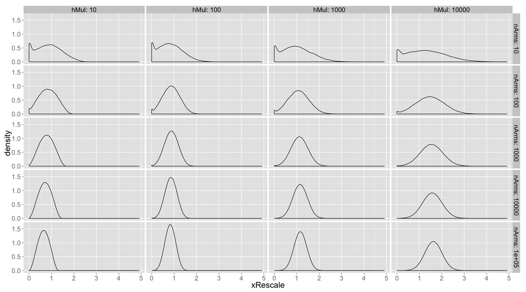

```r
plt2 <- (ggplot(dt)
         + aes(x=xRescale)
         + geom_density()
         + facet_grid(nArms ~ hMul, labeller=label_both))
plt2
```

Now, from these graphs, I would argue that a meaningul proportion of the arms (maybe 50%) are around some constant fraction away from the maximum by this standard deviation factor (ignoring the irrelevant logarithmic factors).